# The Operationalisation of Self-Identity in Reasoned Action Models: Conceptual Independence

Marwin H. M. Snippe, Gjalt-Jorn Y. Peters & Gerjo Kok

12:47:45 on 2019-04-12 CEST (GMT+0200)

```r
###-----------------------------------------------------------------------------
### Load packages
###-----------------------------------------------------------------------------

### Check for presence of packages:
### - userfriendlyscience
### - ufs
### - psych
### - here
### - car

###-----------------------------------------------------------------------------
### Paths and files
###-----------------------------------------------------------------------------

repoPath <- here::here();
workingPath <- here::here("results-intermediate-output");
dataPath <- here::here("results-data");

### Regular expressions that match the private and public datafile names
privateDataFileRegEx <- '\\[PRIVATE]';
publicDataFileRegEx <- '\\[PUBLIC]';
```

```r
behaviors <-
  c("alcohol", "condoms", "exercise");

###-----------------------------------------------------------------------------
### Scale definitions
###-----------------------------------------------------------------------------

scales <- list();

scales$selfIdentitySelected <- c('Selfidentity_kindofperson',
                                 'Selfidentity_seemyselfas',
                                 'Selfidentity_concernedwithdoingtherightbehavior',
                                 'Selfidentity_seemyselffollowingthebehaviorguideline');

scales$selfIdentity <- c('Self-identity:\nSomething I\nrarely think about' = 'Selfidentity_rarelythinkabout',
                         'Self-identity:\n' = 'Selfidentity_kindofperson',
                         'Self-identity:\n' = 'Selfidentity_seemyselfas',
                         'Self-identity:\n' = 'Selfidentity_concernedwithnotdoingthebehaviorenough',
                         'Self-identity:\n' = 'Selfidentity_doingbehaviorimportant',
                         'Self-identity:\n' = 'Selfidentity_importantpart',
                         'Self-identity:\n' = 'Selfidentity_seemyselffollowingthebehaviorguideline',
                         'Self-identity:\n' = 'Selfidentity_wouldfeelatalossgivingupwrongbehavior',
                         'Self-identity:\n' = 'Selfidentity_concernedwithdoingtherightbehavior',
                         'Self-identity:\n' = 'Selfidentity_wrongbehaviormeansmorethanjusttheact',
                         'Self-identity:\n' = 'Selfidentity_behaviormeansmoretantheactself');

scales$attitude <- c('Attitude_bad_good', 'Attitude_unpleasant_pleasant',
                     'Attitude_harmful_beneficial', 'Attitude_boring_interesting');

scales$importance <- c('Importancescale_unimportant_important',
                       'Importancescale_notessential_essential',
                       'Importancescale_notsignificant_significant');

scales$attitudeImportance <- c(scales$attitude, scales$importance);

scales$perceivedNorms <- c('Injunctivenorm_importantpeople',
                           'Injunctivenorm_mostpeopleapprove',
                           'Descriptivenorm_closefriends',
                           'Descriptivenorm_peoplelikeme');

scales$pbc <- c('Perceivedcontrol_forme',
                'Perceivedcontrol_reallywantto',
                'Perceivedcontrol_confident');

scales$intention <- c('Intention_intend',
                      'Intention2willing',
                      'Intention3expect');

scales$pastBehavior <- c('Past_haveused', 'Past_howoften');

scales$currentBehavior <- c('curBeh');

### Specify the items that have to be inverted for all datasets
invertedItems <- c('Selfidentity_rarelythinkabout',
                   'Selfidentity_wouldfeelatalossgivingupwrongbehavior');

### Specify measurement models
measurementModelSpecs <- list();
for (currentScale in names(scales)) {
  measurementModelSpecs[[currentScale]] <- paste0(currentScale, ' =~ ',
                                                  paste0(scales[[currentScale]],
                                                         collapse=" + "));
}

###
nonSIvars <- scales[names(scales) != 'selfIdentity'];

### Generate abbreviated variable names
abbr <- abbreviate(names(scales));
```

# Loading and preparing data

## Data anonymizing and loading

### Overview

Please click “Details” to see the code and output for this step in the analysis procedure.

### Details

```r
###-----------------------------------------------------------------------------
### Columns that potentially identify participants
###-----------------------------------------------------------------------------

### This is
identifyingColumns <-
  list(alcohol = c(1:10, 57:68),
       condoms = c(1:10, 53:64),
       exercise = c(1:10, 55:66));

###-----------------------------------------------------------------------------
### Anonymize data, if necessary
###-----------------------------------------------------------------------------

### Get a list of all data files in data directory
privateDataFiles <-
  list.files(dataPath);

### Select only those matching the regular expression for
### private data files
privateDataFiles <-
  grep(privateDataFileRegEx,
       privateDataFiles,
       value=TRUE);

if (length(privateDataFiles) > 0) {
  ### Private data files are present; this means we run on the PC
  ### of one of the researchers. That means we should sanitize the
  ### datasets and prepare them for publishing.

  ### Loop through the files
  for (currentFilename in privateDataFiles) {

    ### Run within local, temporary namespace (so that all variables
    ### are deleted afterwards)
    local({

      ### Read this dataset into a temporary, locally stored dataframe
      dat <-
        userfriendlyscience::getData(file.path(dataPath,
                                               currentFilename), skip=1);
      ufs::cat0("Read data file '", currentFilename, "'.\n");

      ### Identify which columns to use for this datafile
      currentBehavior <-
        names(identifyingColumns)[unlist(lapply(names(identifyingColumns),
                                                grepl,
                                                currentFilename))];
      currentIdCols <-
        identifyingColumns[[currentBehavior]];

      ### Anonymize the potentially identifying columns
      for (currentVar in currentIdCols) {
        dat[, currentVar] <-
          anonymizer::anonymize(dat[, currentVar]);
      }

      ### Construct new filename to write public version of data to
      newTmpFilename <- sub(privateDataFileRegEx,
                            publicDataFileRegEx,
                            currentFilename);

      ### Store new datafile
      write.csv(dat,
                file.path(dataPath,
                          newTmpFilename),
                row.names = FALSE);

      ufs::cat0("Stored data file '", newTmpFilename, "'.\n");

    });  ### End local namespace

  }
}
```

```
## Read data file 'alcohol_[PRIVATE].csv'.
## Stored data file 'alcohol_[PUBLIC].csv'.
## Read data file 'condoms_[PRIVATE].csv'.
## Stored data file 'condoms_[PUBLIC].csv'.
## Read data file 'exercise_[PRIVATE].csv'.
## Stored data file 'exercise_[PUBLIC].csv'.
```

```r
###-----------------------------------------------------------------------------
### Load public datafiles
###-----------------------------------------------------------------------------

### Get a list of all data files in data directory
publicDataFiles <-
  list.files(dataPath);

### Select only those matching the regular expression for
### private data files
publicDataFiles <-
  grep(publicDataFileRegEx,
       publicDataFiles,
       value=TRUE);

### Create object to store datafiles
dat <- list();

### Load datafiles into objects
for (currentDataset in publicDataFiles) {
  ### Read datafile from disk
  dat[[currentDataset]] <-
    userfriendlyscience::getData(file.path(dataPath,
                                           currentDataset), skip=1);
}

names(dat) <-
  behaviors;

dat.raw <- dat;
```

## Data cleaning

### Overview

Please click “Details” to see the code and output for this step in the analysis procedure.

### Details

```r
###-----------------------------------------------------------------------------
### Clean data
###-----------------------------------------------------------------------------

### Delete last variable (Qualtrics apparently ends lines with a comma?)
dat <-
  lapply(dat,
         function(x) {
           return(x[, names(x) != 'X']);
         });

### Apply nrow to each list element to see number of rows in the dataframes
lapply(dat, nrow);
```

```
## $alcohol
## [1] 302
##
## $condoms
## [1] 250
##
## $exercise
## [1] 250
```

```r
### Sum sample sizes to get total sample size
sum(unlist(lapply(dat, nrow)));
```

```
## [1] 802
```

```r
### Verify ranges for those variables with fixes answer options
### for each questionnaire (Qualtrics sometimes has odd minimum and
### maximum values)
lapply(dat.raw,
       function(x) {
         rws <- 16:(ncol(x)-13);
         x <- ufs::massConvertToNumeric(x[, rws]);
         lapply(x, range, na.rm=TRUE);
       });
```

```
## $alcohol
## $alcohol$X9
## [1]  9 10
##
## $alcohol$NA..1
## [1] 1 1
##
## $alcohol$X1.1
## [1] 1 1
##
## $alcohol$X25
## [1] 20 26
##
## $alcohol$X44
## [1] 27 47
##
## $alcohol$X17
## [1] 14 20
##
## $alcohol$X10
## [1]  9 16
##
## $alcohol$X3
## [1] 1 7
##
## $alcohol$X4
## [1] 1 7
##
## $alcohol$X4.1
## [1] 1 7
##
## $alcohol$X5
## [1] 1 7
##
## $alcohol$X4.2
## [1] 1 7
##
## $alcohol$X5.1
## [1] 1 7
##
```

[output cut: 300 more lines]

```
##
## $exercise$X5.7
## [1] 1 7
##
## $exercise$X5.8
## [1] 1 7
##
## $exercise$X1.4
## [1] 1 1
##
## $exercise$X5.9
## [1] 1 7
##
## $exercise$X33
## [1] 28 34
```

```r
###-----------------------------------------------------------------------------
### Add a unique identifier to every participant
###-----------------------------------------------------------------------------

for (currentBehav in names(dat)) {
  dat[[currentBehav]]$id <-
    paste0(currentBehav,
           "_",
           1:nrow(dat[[currentBehav]]));
}
```

```r
###-----------------------------------------------------------------------------
### Rename variables to a consistent naming scheme
###-----------------------------------------------------------------------------

### Note that the order of the dataframes (stored in 'behavior') is alcohol,
### condom use, and exercise.

names(dat[[1]])[1] <- 'ResponseID';
names(dat[[1]])[2] <- 'ResponseSet';
names(dat[[1]])[3] <- 'Name';
names(dat[[1]])[4] <- 'ExternalDataReference';
names(dat[[1]])[5] <- 'EmailAddress';
names(dat[[1]])[6] <- 'IPAddress';
names(dat[[1]])[7] <- 'Status';
names(dat[[1]])[8] <- 'StartDate';
names(dat[[1]])[9] <- 'EndDate';
names(dat[[1]])[10] <- 'Finished';
names(dat[[1]])[11] <- 'informedConsent';
names(dat[[1]])[12] <- 'age';
names(dat[[1]])[13] <- 'studyExit';
names(dat[[1]])[14] <- 'sex';
names(dat[[1]])[15] <- 'country';
names(dat[[1]])[16] <- 'selectionAlcohol';
names(dat[[1]])[17] <- 'negativeresponsSelectionAlcohol';
names(dat[[1]])[18] <- 'informationAlcohol';
names(dat[[1]])[19] <- 'Intention_intend';
names(dat[[1]])[20] <- 'Intention2willing';
names(dat[[1]])[21] <- 'Intention3expect';
names(dat[[1]])[22] <- 'curBeh';
names(dat[[1]])[23] <- 'Attitude_bad_good';
names(dat[[1]])[24] <- 'Attitude_unpleasant_pleasant';
names(dat[[1]])[25] <- 'Attitude_harmful_beneficial';
names(dat[[1]])[26] <- 'Attitude_boring_interesting';
names(dat[[1]])[27] <- 'Importancescale_unimportant_important';
names(dat[[1]])[28] <- 'Importancescale_notessential_essential';
names(dat[[1]])[29] <- 'Importancescale_notsignificant_significant';
names(dat[[1]])[30] <- 'information';
names(dat[[1]])[31] <- 'Injunctivenorm_importantpeople';
names(dat[[1]])[32] <- 'Injunctivenorm_mostpeopleapprove';
names(dat[[1]])[33] <- 'Descriptivenorm_closefriends';
names(dat[[1]])[34] <- 'Descriptivenorm_peoplelikeme';
names(dat[[1]])[35] <- 'Perceivedcontrol_forme';
names(dat[[1]])[36] <- 'Perceivedcontrol_reallywantto';
names(dat[[1]])[37] <- 'Perceivedcontrol_confident';
names(dat[[1]])[38] <- 'information';
names(dat[[1]])[39] <- 'Selfidentity_rarelythinkabout';
names(dat[[1]])[40] <- 'SelfidentityRestrainedAlcohol';
names(dat[[1]])[41] <- 'Selfidentity_kindofperson';
names(dat[[1]])[42] <- 'Selfidentity_restrainedalcoholimportant';
names(dat[[1]])[43] <- 'Selfidentity_doingbehaviorimportant';
names(dat[[1]])[44] <- 'Selfidentity_importantpart';
names(dat[[1]])[45] <- 'Selfidentity_seemyselfas';
names(dat[[1]])[46] <- 'Selfidentity_seemyselffollowingthebehaviorguideline';
names(dat[[1]])[47] <- 'Selfidentity_givingupalcoholdrinking';
names(dat[[1]])[48] <- 'Selfidentity_restrainedalcoholdrinkingmeansmore';
names(dat[[1]])[49] <- 'Selfidentity_wrongbehaviormeansmorethanjusttheact';
names(dat[[1]])[50] <- 'Selfidentity_behaviormeansmoretantheactself';
names(dat[[1]])[51] <- 'Selfidentity_concernedwithnotdoingthebehaviorenough';
names(dat[[1]])[52] <- 'Selfidentity_concernedwithdoingtherightbehavior';
names(dat[[1]])[53] <- 'Selfidentity_wouldfeelatalossgivingupwrongbehavior';
names(dat[[1]])[54] <- 'information';
names(dat[[1]])[55] <- 'Past_haveused';
names(dat[[1]])[56] <- 'Past_howoften';
names(dat[[1]])[57] <- 'VerificationWorkerID';
names(dat[[1]])[58] <- 'Endscreen';
names(dat[[1]])[59] <- 'Browser.Meta.Info.Browser';
names(dat[[1]])[60] <- 'Browser.Meta.Info.Version';
names(dat[[1]])[61] <- 'Browser.Meta.Info.Operating.System';
names(dat[[1]])[62] <- 'Browser.Meta.Info.Screen.Resolution';
names(dat[[1]])[63] <- 'Browser.Meta.Info.Flash.Version';
names(dat[[1]])[64] <- 'Browser.Meta.Info.Java.Support';
names(dat[[1]])[65] <- 'Browser.Meta.Info.User.Agent';
names(dat[[1]])[66] <- 'LocationLatitude';
names(dat[[1]])[67] <- 'LocationLongitude';
names(dat[[1]])[68] <- 'LocationAccuracy';

names(dat[[2]])[1] <- 'ResponseID';
names(dat[[2]])[2] <- 'ResponseSet';
names(dat[[2]])[3] <- 'Name';
names(dat[[2]])[4] <- 'ExternalDataReference';
names(dat[[2]])[5] <- 'EmailAddress';
names(dat[[2]])[6] <- 'IPAddress';
names(dat[[2]])[7] <- 'Status';
names(dat[[2]])[8] <- 'StartDate';
names(dat[[2]])[9] <- 'EndDate ';
names(dat[[2]])[10] <- 'Finished';
names(dat[[2]])[11] <- 'informedConsent';
names(dat[[2]])[12] <- 'age';
names(dat[[2]])[13] <- 'studyExit';
names(dat[[2]])[14] <- 'sex';
names(dat[[2]])[15] <- 'country';
names(dat[[2]])[16] <- 'selectionCondom';
names(dat[[2]])[17] <- 'studyExit';
names(dat[[2]])[18] <- 'information';
names(dat[[2]])[19] <- 'Intention_intend';
names(dat[[2]])[20] <- 'Intention2willing';
names(dat[[2]])[21] <- 'Intention3expect';
names(dat[[2]])[22] <- 'curBeh';
names(dat[[2]])[23] <- 'Attitude_bad_good';
names(dat[[2]])[24] <- 'Attitude_unpleasant_pleasant';
names(dat[[2]])[25] <- 'Attitude_harmful_beneficial';
names(dat[[2]])[26] <- 'Attitude_boring_interesting';
names(dat[[2]])[27] <- 'Importancescale_unimportant_important';
names(dat[[2]])[28] <- 'Importancescale_notessential_essential';
names(dat[[2]])[29] <- 'Importancescale_notsignificant_significant';
names(dat[[2]])[30] <- 'information';
names(dat[[2]])[31] <- 'Injunctivenorm_importantpeople';
names(dat[[2]])[32] <- 'Injunctivenorm_mostpeopleapprove';
names(dat[[2]])[33] <- 'Descriptivenorm_closefriends';
names(dat[[2]])[34] <- 'Descriptivenorm_peoplelikeme';
names(dat[[2]])[35] <- 'Perceivedcontrol_forme';
names(dat[[2]])[36] <- 'Perceivedcontrol_reallywantto';
names(dat[[2]])[37] <- 'Perceivedcontrol_confident';
names(dat[[2]])[38] <- 'information';
names(dat[[2]])[39] <- 'Selfidentity_rarelythinkabout';
names(dat[[2]])[40] <- 'Selfidentity_kindofperson';
names(dat[[2]])[41] <- 'Selfidentity_importantpart';
names(dat[[2]])[42] <- 'Selfidentity_doingbehaviorimportant';
names(dat[[2]])[43] <- 'Selfidentity_seemyselfas';
names(dat[[2]])[44] <- 'Selfidentity_behaviormeansmoretantheactself';
names(dat[[2]])[45] <- 'Selfidentity_seemyselffollowingthebehaviorguideline';
names(dat[[2]])[46] <- 'Selfidentity_concernedwithnotdoingthebehaviorenough';
names(dat[[2]])[47] <- 'Selfidentity_concernedwithdoingtherightbehavior';
names(dat[[2]])[48] <- 'Selfidentity_wouldfeelatalossgivingupwrongbehavior';
names(dat[[2]])[49] <- 'Selfidentity_wrongbehaviormeansmorethanjusttheact';
names(dat[[2]])[50] <- 'information';
names(dat[[2]])[51] <- 'Past_haveused';
names(dat[[2]])[52] <- 'Past_howoften';
names(dat[[2]])[53] <- 'VerificationWorkerID';
names(dat[[2]])[54] <- 'Endscreen';
names(dat[[2]])[55] <- 'Browser.Meta.Info.Browser';
names(dat[[2]])[56] <- 'Browser.Meta.Info.Version';
names(dat[[2]])[57] <- 'Browser.Meta.Info.Operating.System';
names(dat[[2]])[58] <- 'Browser.Meta.Info.Screen.Resolution';
names(dat[[2]])[59] <- 'Browser.Meta.Info.Flash.Version';
names(dat[[2]])[60] <- 'Browser.Meta.Info.Java.Support';
names(dat[[2]])[61] <- 'Browser.Meta.Info.User.Agent';
names(dat[[2]])[62] <- 'LocationLatitude';
names(dat[[2]])[63] <- 'LocationLongitude';
names(dat[[2]])[64] <- 'LocationAccuracy';

names(dat[[3]])[1] <- 'ResponseID';
names(dat[[3]])[2] <- 'ResponseSet';
names(dat[[3]])[3] <- 'Name';
names(dat[[3]])[4] <- 'ExternalDataReference';
names(dat[[3]])[5] <- 'EmailAddress';
names(dat[[3]])[6] <- 'IPAddress';
names(dat[[3]])[7] <- 'Status';
names(dat[[3]])[8] <- 'StartDate';
names(dat[[3]])[9] <- 'EndDate';
names(dat[[3]])[10] <- 'Finished';
names(dat[[3]])[11] <- 'informedConsent';
names(dat[[3]])[12] <- 'age';
names(dat[[3]])[13] <- 'studyExit';
names(dat[[3]])[14] <- 'sex';
names(dat[[3]])[15] <- 'country';
names(dat[[3]])[16] <- 'information';
names(dat[[3]])[17] <- 'Intention_intend';
names(dat[[3]])[18] <- 'Intention2willing';
names(dat[[3]])[19] <- 'Intention3expect';
names(dat[[3]])[20] <- 'curBeh';
names(dat[[3]])[21] <- 'Attitude_bad_good';
names(dat[[3]])[22] <- 'Attitude_unpleasant_pleasant';
names(dat[[3]])[23] <- 'Attitude_harmful_beneficial';
names(dat[[3]])[24] <- 'Attitude_boring_interesting';
names(dat[[3]])[25] <- 'Importancescale_unimportant_important';
names(dat[[3]])[26] <- 'Importancescale_notessential_essential';
names(dat[[3]])[27] <- 'Importancescale_notsignificant_significant';
names(dat[[3]])[28] <- 'information';
names(dat[[3]])[29] <- 'Injunctivenorm_importantpeople';
names(dat[[3]])[30] <- 'Injunctivenorm_mostpeopleapprove';
names(dat[[3]])[31] <- 'Descriptivenorm_closefriends';
names(dat[[3]])[32] <- 'Descriptivenorm_peoplelikeme';
names(dat[[3]])[33] <- 'Perceivedcontrol_forme';
names(dat[[3]])[34] <- 'Perceivedcontrol_reallywantto';
names(dat[[3]])[35] <- 'Perceivedcontrol_confident';
names(dat[[3]])[36] <- 'information';
names(dat[[3]])[37] <- 'Selfidentity_rarelythinkabout';
names(dat[[3]])[38] <- 'Selfidentity_kindofperson';
names(dat[[3]])[39] <- 'Selfidentity_exercisingenoughimportant';
names(dat[[3]])[40] <- 'Selfidentity_notthinkingaboutexercisingregularly';
names(dat[[3]])[41] <- 'Selfidentity_seemyselfas';
names(dat[[3]])[42] <- 'Selfidentity_concernedwithnotdoingthebehaviorenough';
names(dat[[3]])[43] <- 'Selfidentity_doingbehaviorimportant';
names(dat[[3]])[44] <- 'Selfidentity_importantpart';
names(dat[[3]])[45] <- 'Selfidentity_seemyselffollowingthebehaviorguideline';
names(dat[[3]])[46] <- 'Selfidentity_wouldfeelatalossgivingupwrongbehavior';
names(dat[[3]])[47] <- 'Selfidentity_lossgivingupexercising';
names(dat[[3]])[48] <- 'Selfidentity_concernedwithdoingtherightbehavior';
names(dat[[3]])[49] <- 'Selfidentity_exercisingenoughmeansmore';
names(dat[[3]])[50] <- 'Selfidentity_wrongbehaviormeansmorethanjusttheact';
names(dat[[3]])[51] <- 'Selfidentity_behaviormeansmoretantheactself';
names(dat[[3]])[52] <- 'information';
names(dat[[3]])[53] <- 'Past_haveused';
names(dat[[3]])[54] <- 'Past_howoften';
names(dat[[3]])[55] <- 'VerificationWorkerID';
names(dat[[3]])[56] <- 'Endscreen';
names(dat[[3]])[57] <- 'Browser.Meta.Info.Browser';
names(dat[[3]])[58] <- 'Browser.Meta.Info.Version';
names(dat[[3]])[59] <- 'Browser.Meta.Info.Operating.System';
names(dat[[3]])[60] <- 'Browser.Meta.Info.Screen.Resolution';
names(dat[[3]])[61] <- 'Browser.Meta.Info.Flash.Version';
names(dat[[3]])[62] <- 'Browser.Meta.Info.Java.Support';
names(dat[[3]])[63] <- 'Browser.Meta.Info.User.Agent';
names(dat[[3]])[64] <- 'LocationLatitude';
names(dat[[3]])[65] <- 'LocationLongitude';
names(dat[[3]])[66] <- 'LocationAccuracy';
```

## Data recoding

### Overview

Please click “Details” to see the code and output for this step in the analysis procedure.

### Details

```r
###-----------------------------------------------------------------------------
### Recode the variables
###-----------------------------------------------------------------------------

### All three behaviors
dat <-
  lapply(dat, function(x) {
    ### This is mostly to fix some weird codings from Qualtrics
    x$Intention_intend <-
      car::recode(x$Intention_intend, "20=1; 21=2; 22=3; 23=4; 24=5; 25=6; 26=7");
    x$Intention2willing <-
      car::recode(x$Intention2willing, "43=1; 44=2; 45=3; 46=4; 47=5; 27=6; 28=7");
    x$Intention3expect <-
      car::recode(x$Intention3expect, "14=1; 15=2; 16=3; 17=4; 18=5; 19=6; 20=7");
    x$curBeh <-
      car::recode(x$curBeh, "9=1; 10=2; 11=3; 12=4; 14=5; 15=6; 16=7");
    x$Injunctivenorm_importantpeople <-
      car::recode(x$Injunctivenorm_importantpeople, "40=1; 41=2; 42=3; 43=4; 44=5; 45=6; 46=7; 47=NA");
    x$Descriptivenorm_peoplelikeme <-
      car::recode(x$Descriptivenorm_peoplelikeme, "15=1; 16=2; 17=3; 18=4; 19=5; 20=6; 21=7; 22=NA");
    x$Perceivedcontrol_forme <-
      car::recode(x$Perceivedcontrol_forme, "22=1; 23=2; 24=3; 25=4; 26=5; 27=6; 28=7");
    x$Perceivedcontrol_reallywantto <-
      car::recode(x$Perceivedcontrol_reallywantto, "9=1; 18=2; 10=3; 11=4; 12=5; 13=6; 14=7");
    x$Past_howoften <-
      car::recode(x$Past_howoften, "28=1; 29=2; 30=3; 31=4; 32=5; 33=6; 34=7");

    ### We still have to decide what to do with people who say "don't know" - currently,
    ### setting it to 3.9999, which approaches 4, but is still recognizable.
    x$Descriptivenorm_closefriends <-
      car::recode(x$Descriptivenorm_closefriends, "8=3.9999");
    x$Injunctivenorm_mostpeopleapprove <-
      car::recode(x$Injunctivenorm_mostpeopleapprove, "8=3.9999");

    # x$Injunctivenorm_importantpeople[which(is.na(x$Injunctivenorm_importantpeople))] <-
    #   mean(x$Injunctivenorm_importantpeople, na.rm = TRUE);
    # x$Descriptivenorm_peoplelikeme[which(is.na(x$Descriptivenorm_peoplelikeme))] <-
    #   mean(x$Descriptivenorm_peoplelikeme, na.rm = TRUE);
    # x$Descriptivenorm_closefriends[which(is.na(x$Descriptivenorm_closefriends))] <-
    #   mean(x$Descriptivenorm_closefriends, na.rm = TRUE);
    # x$Injunctivenorm_mostpeopleapprove[which(is.na(x$Injunctivenorm_mostpeopleapprove))] <-
    #   mean(x$Injunctivenorm_mostpeopleapprove, na.rm = TRUE);

    ### Inversions for all datasets
    x <-
      userfriendlyscience::invertItems(x, invertedItems);

    return(x);
  });

### Alcohol only
 dat[[1]]$selectionAlcohol <-
   userfriendlyscience::invertItem(dat[[1]]$selectionAlcohol - 9);
 dat[[1]]$SelfidentityRestrainedAlcohol <-
   userfriendlyscience::invertItem(dat[[1]]$SelfidentityRestrainedAlcohol);
 dat[[1]]$Selfidentity_importantpart <-
   userfriendlyscience::invertItem(dat[[1]]$Selfidentity_importantpart, c(1, 6));
 dat[[1]]$Selfidentity_givingupalcoholdrinking <-
   userfriendlyscience::invertItem(dat[[1]]$Selfidentity_givingupalcoholdrinking, c(1, 6));
 dat[[1]]$Selfidentity_behaviormeansmoretantheactself <-
   userfriendlyscience::invertItem(dat[[1]]$Selfidentity_behaviormeansmoretantheactself, c(1, 6));

### Exercise only
 dat[[3]]$Selfidentity_notthinkingaboutexercisingregularly <-
   userfriendlyscience::invertItem(dat[[3]]$Selfidentity_notthinkingaboutexercisingregularly, c(1, 6));
 dat[[3]]$Selfidentity_exercisingenoughimportant <-
   userfriendlyscience::invertItem(dat[[3]]$Selfidentity_exercisingenoughimportant, c(1, 6));
 dat[[3]]$Selfidentity_exercisingenoughmeansmore <-
   userfriendlyscience::invertItem(dat[[3]]$Selfidentity_exercisingenoughmeansmore, c(1, 6));
```

## Splitting datasets per country

### Overview

Please click “Details” to see the code and output for this step in the analysis procedure.

### Details

```r
###-----------------------------------------------------------------------------
### Splitting datasets per country
###-----------------------------------------------------------------------------

for (i in behaviors) {
  dat[[paste0(i, '_us')]] <-
    dat[[i]][dat[[i]]$country == 1, ];
  dat[[paste0(i, '_india')]] <-
    dat[[i]][dat[[i]]$country == 2, ];
}
```

## Creating scales

### Overview

Please click “Details” to see the code and output for this step in the analysis procedure.

### Details

```r
###-----------------------------------------------------------------------------
### Create the scales and add them to the dataframes
###-----------------------------------------------------------------------------

for (i in names(dat)) {
  dat[[i]] <-
    ufs::makeScales(dat[[i]], scales);
}

### Store dataframes in other object and create new
### object with only the six separate samples
datFull <-
  dat;
dat <-
  dat[grepl("_", names(dat))];
```

## Remove excluded, straightlining and careless participants

### Overview

Please click “Details” to see the code and output for this step in the analysis procedure.

### Details

```r
###-----------------------------------------------------------------------------
### Remove participants that were screened out
###-----------------------------------------------------------------------------

### Participants who were screened out have a non-NA value for 'studyExit'
for (currentDataset in names(dat)) {
  dat[[currentDataset]] <-
    dat[[currentDataset]][is.na(dat[[currentDataset]]$studyExit), ];
}


###-----------------------------------------------------------------------------
### Detect straightlining and careless participants
###-----------------------------------------------------------------------------

suspectParticipants <-
  list();

for (currentDataset in names(dat)) {
  ### Get a vector with only the numeric variables
  numericVars <-
    unlist(lapply(dat[[currentDataset]], is.numeric));
  ### Store results from the `careless` package functions
  suspectParticipants[[currentDataset]] <-
    list(longstring = careless::longstring(dat[[currentDataset]][, numericVars]),
         irv = careless::irv(dat[[currentDataset]][, numericVars],
                             split = TRUE,
                             num.split = 4)
         ### The mahalanobis function gives an error:
         ###   Error in solve.default(Sx) :
         ###     Lapack routine dgesv: system is exactly singular: U[1,1] = 0
#         , mahalanobis = careless::mahad(dat[[currentDataset]][, numericVars])
         );
  ### Some housecleaning
  rm(numericVars);
}

### Show box plots for longstring
for (currentDataset in names(dat)) {
  ufs::cat0("\n\n#### Longstring analysis for ", currentDataset, "\n\n");
  userfriendlyscience::knitFig(
    userfriendlyscience::ggBoxplot(data.frame(longstring=suspectParticipants[[currentDataset]]$longstring,
                                              id=dat[[currentDataset]]$id),
                                   y='longstring'),
                               figCaption=paste0("Boxplot for longstring in ", currentDataset));
  longstringThreshold <-
    min(boxplot(suspectParticipants[[currentDataset]]$longstring)$out);
  longStringTooHigh <-
    suspectParticipants[[currentDataset]]$longstring >= longstringThreshold;
  ufs::cat0("\n\n**Ids of outliers in this boxplot:** ",
            ufs::vecTxtQ(dat[[currentDataset]][longStringTooHigh, 'id']), "\n\n");
  ### Some housekeeping
  rm(longstringThreshold);
}
```

#### Longstring analysis for alcohol_us

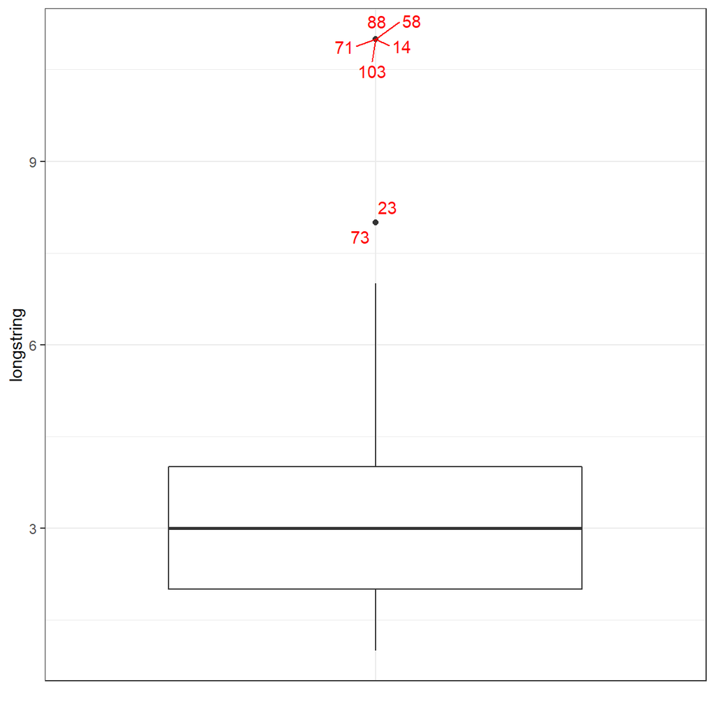

Boxplot for longstring in alcohol_us

**Ids of outliers in this boxplot:** ‘alcohol_131’, ‘alcohol_140’, ‘alcohol_175’, ‘alcohol_188’, ‘alcohol_190’, ‘alcohol_205’ & ‘alcohol_220’

#### Longstring analysis for alcohol_india

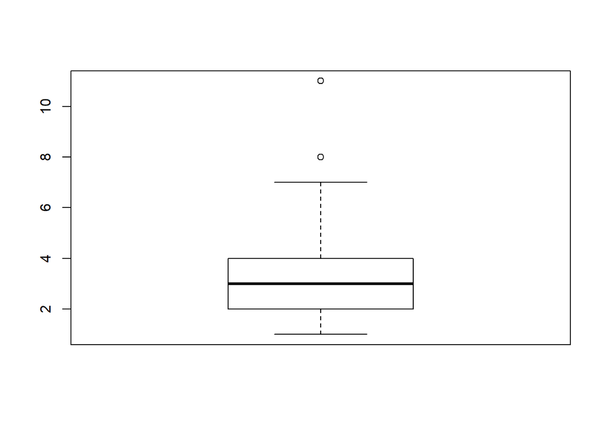

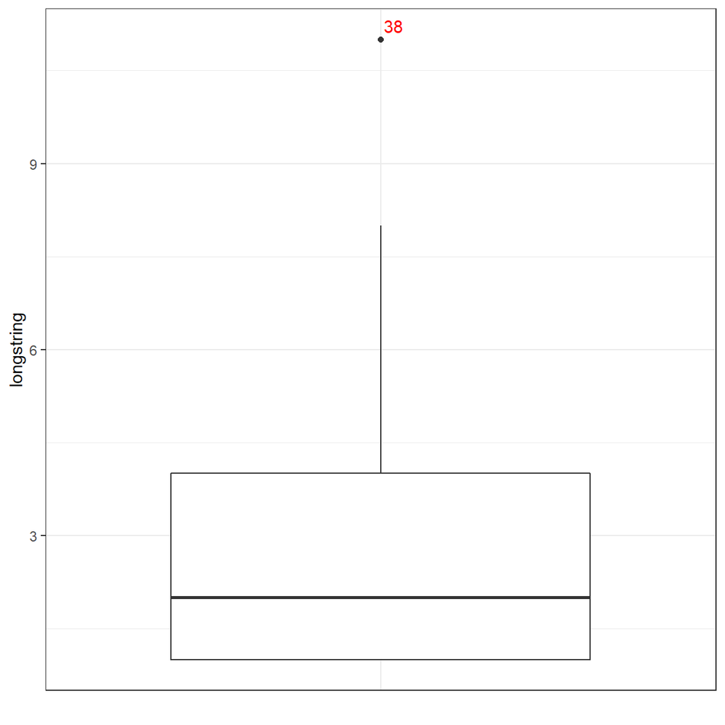

Boxplot for longstring in alcohol_india

**Ids of outliers in this boxplot:** ‘alcohol_39’

#### Longstring analysis for condoms_us

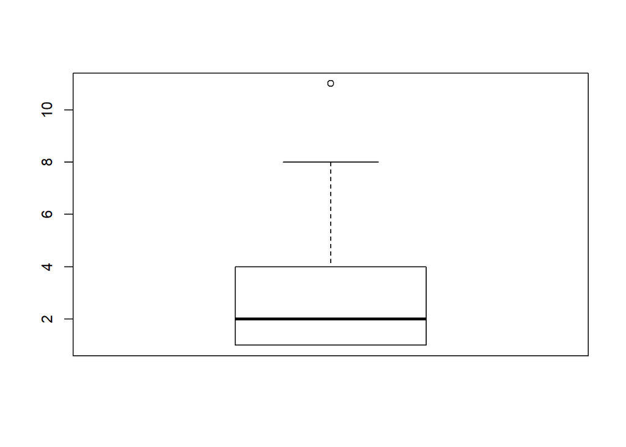

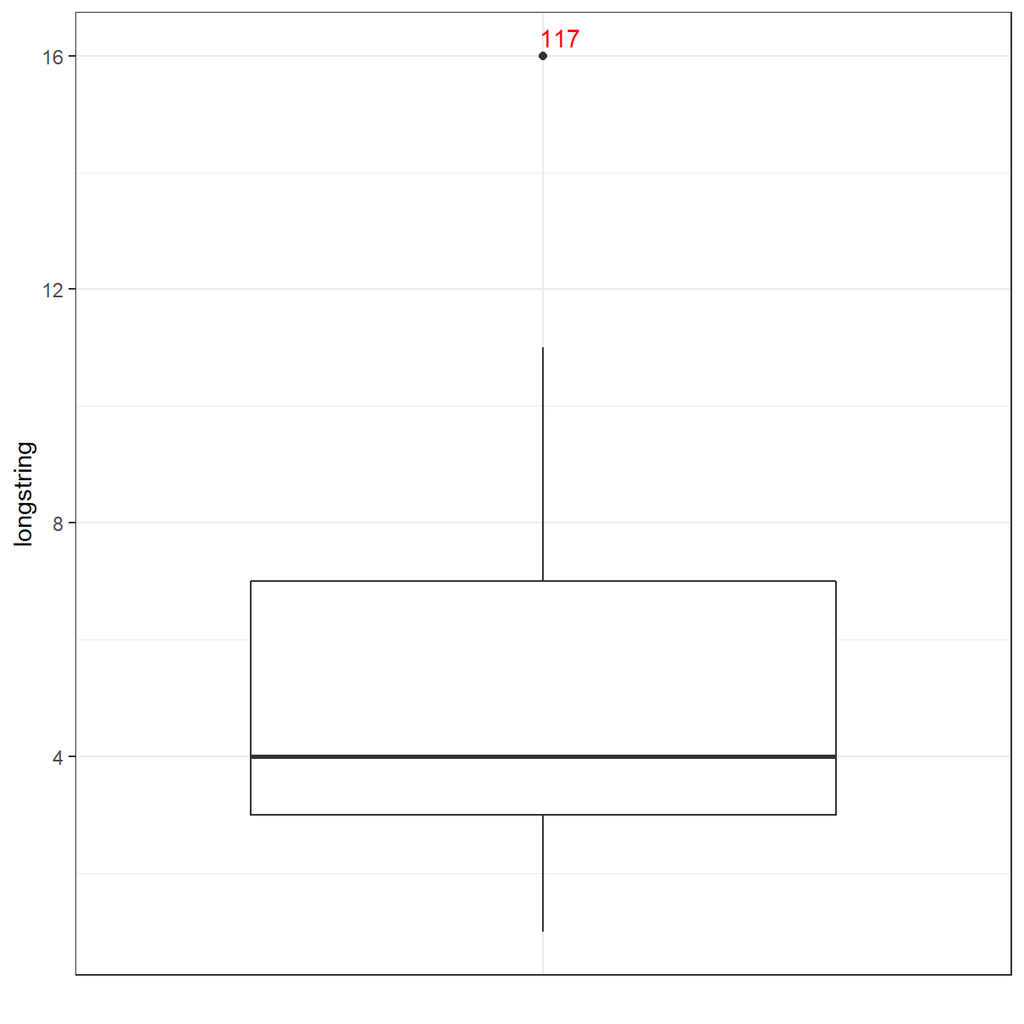

Boxplot for longstring in condoms_us

**Ids of outliers in this boxplot:** ‘condoms_223’

#### Longstring analysis for condoms_india

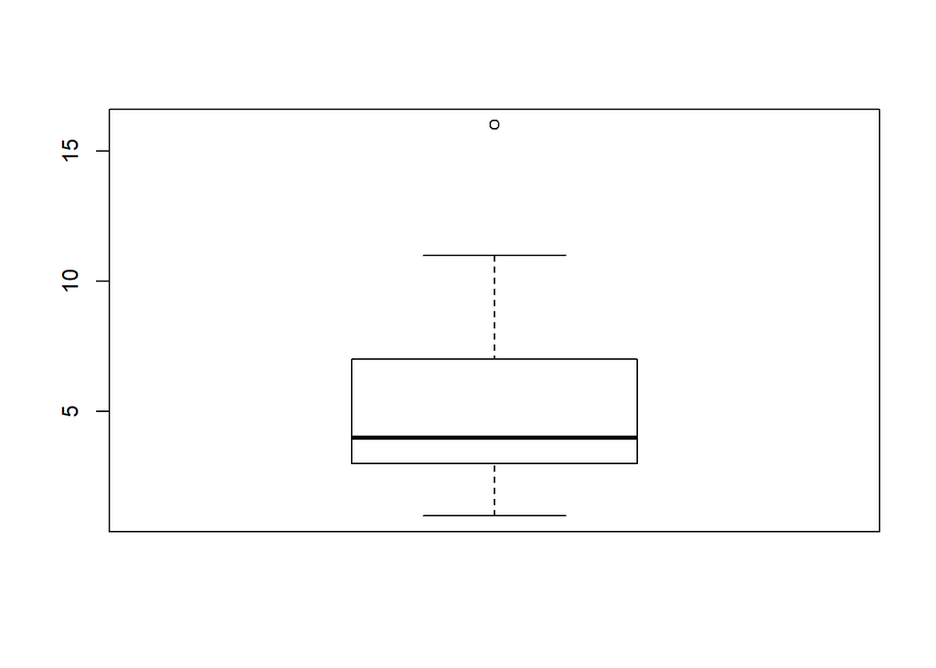

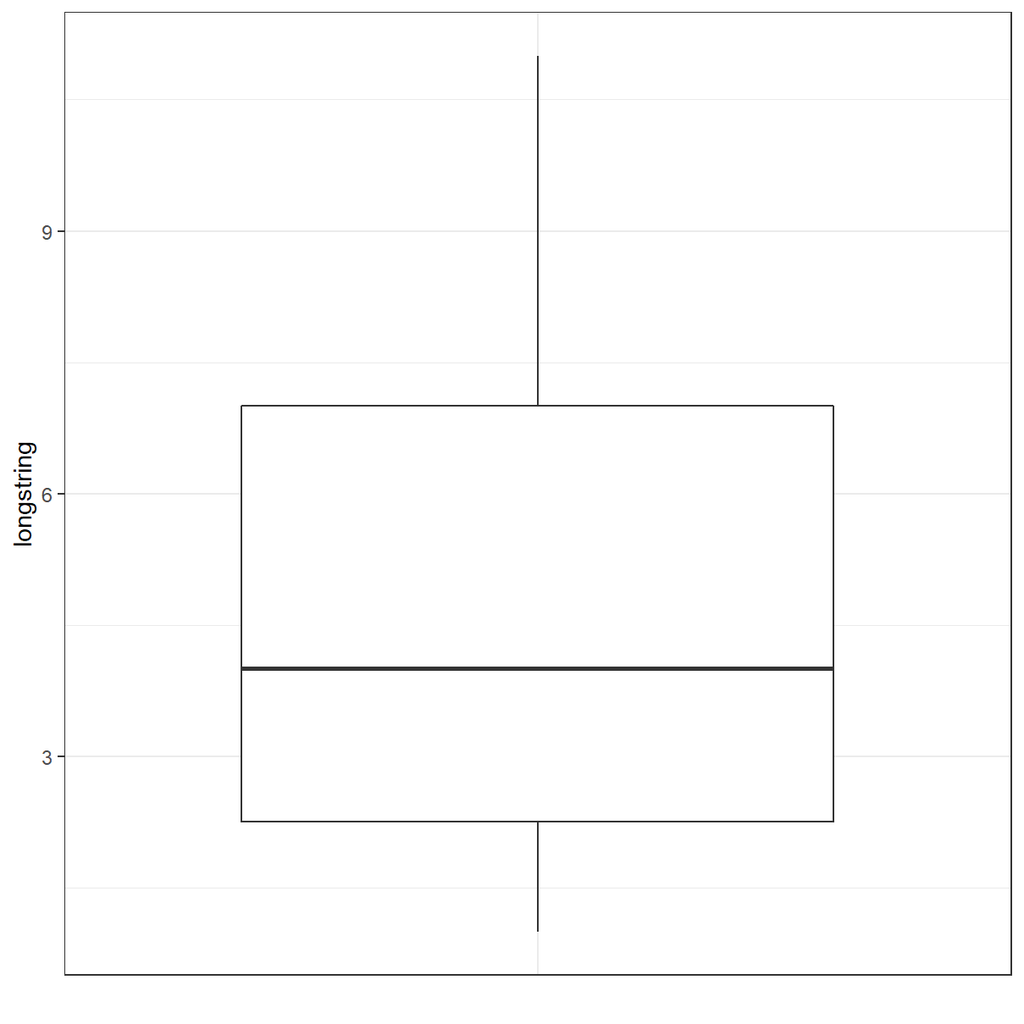

Boxplot for longstring in condoms_india

**Ids of outliers in this boxplot:** ’’

#### Longstring analysis for exercise_us

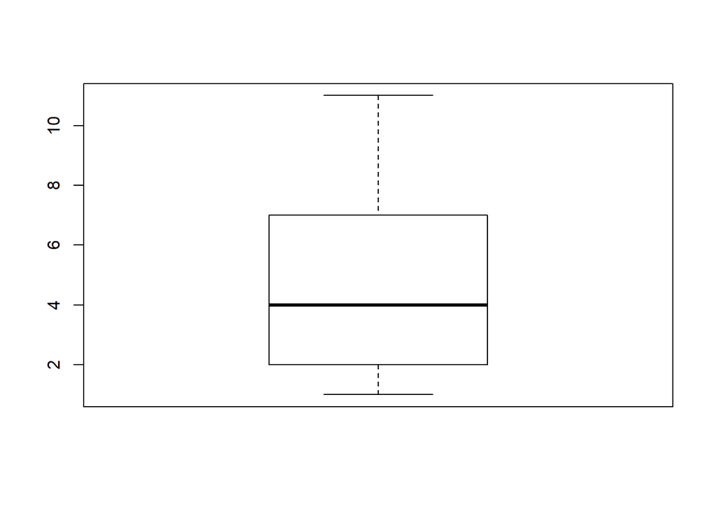

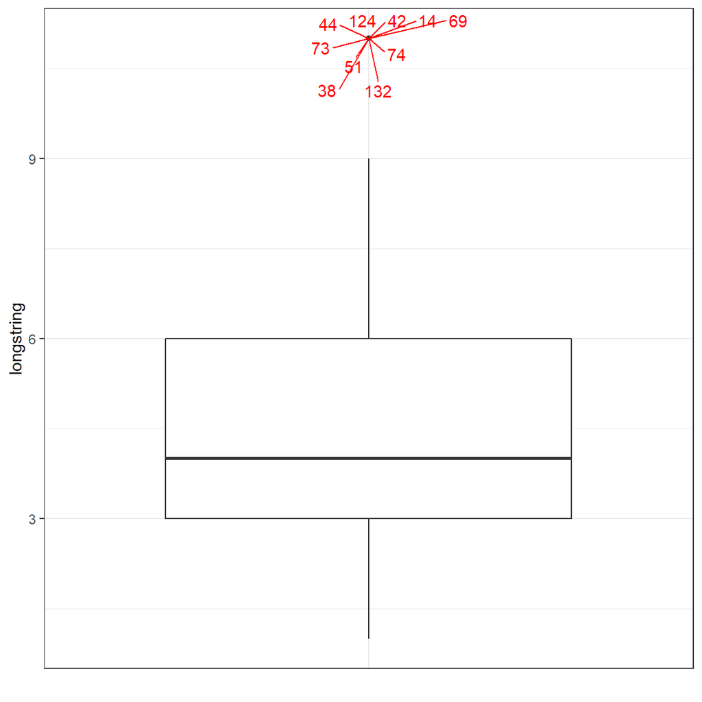

Boxplot for longstring in exercise_us

**Ids of outliers in this boxplot:** ‘exercise_116’, ‘exercise_140’, ‘exercise_144’, ‘exercise_146’, ‘exercise_153’, ‘exercise_171’, ‘exercise_175’, ‘exercise_176’, ‘exercise_230’ & ‘exercise_238’

#### Longstring analysis for exercise_india

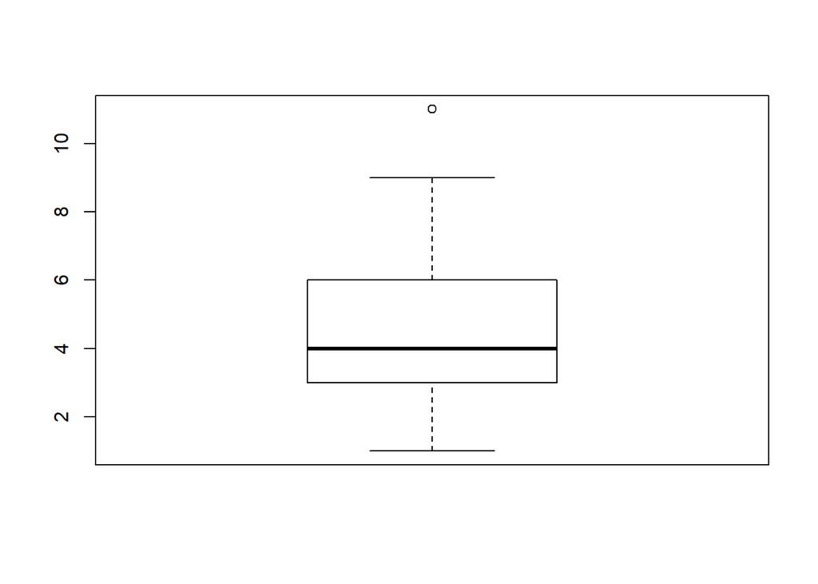

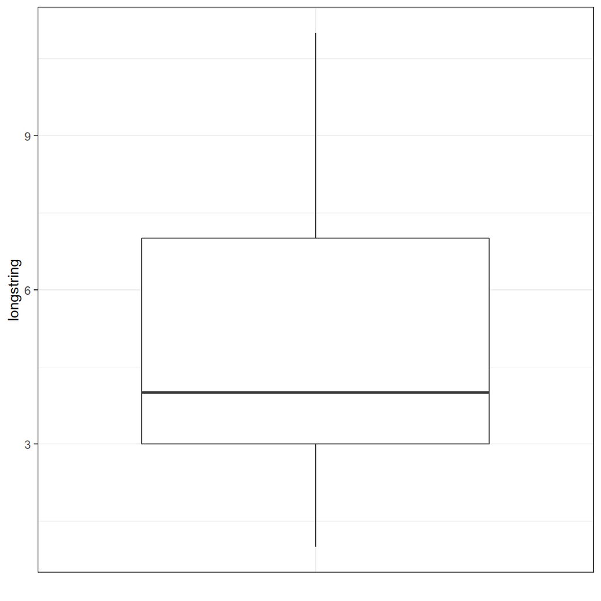

Boxplot for longstring in exercise_india

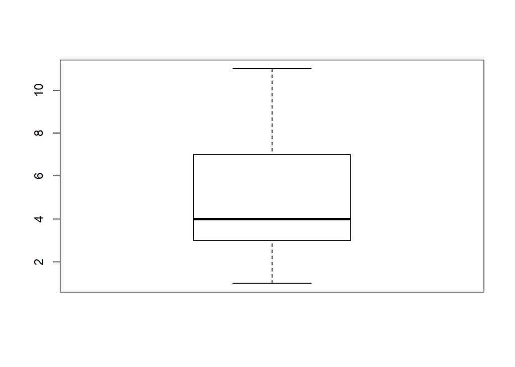

**Ids of outliers in this boxplot:** ’’

```r
### Do something with the IRV
```

## Saving processed data

### Overview

Please click “Details” to see the code and output for this step in the analysis procedure.

### Details

```r
###-----------------------------------------------------------------------------
### Create the scales and add them to the dataframes
###-----------------------------------------------------------------------------

for (currentDataset in names(dat)) {
  ### Store new datafile
  write.csv(dat[[currentDataset]],
            file.path(dataPath,
                      paste0(currentDataset, "_processed.csv")),
            row.names = FALSE);
  ufs::cat0("Stored data file '", currentDataset, "_processed.csv'.\n");
}
```

```
## Stored data file 'alcohol_us_processed.csv'.
## Stored data file 'alcohol_india_processed.csv'.
## Stored data file 'condoms_us_processed.csv'.
## Stored data file 'condoms_india_processed.csv'.
## Stored data file 'exercise_us_processed.csv'.
## Stored data file 'exercise_india_processed.csv'.
```